# Creating Scaleable and Reproducible Workflows in Genomics

## Parallelising Code

While the above code is helpful, some low-level programs do not exploit parallel processing. Here we apply some a QC measuring program called FastQC (from the Babraham Institute).

```bash
# fastqc analysis (creating output folder first as required)
mkdir -p fastqc_data

# conventional run on a folder
#fastqc -o fastqc_data $OUTDIR/*.fastq*

# let's make use of GNU Parallel
find $OUTDIR/*.fastq* | parallel -j ${NUMCPUS} "fastqc -o fastqc_data {}"

# Acknowledge program and link to other run modes.
```

## Quality Control

The program MultiQC is good at producing graphical summaries of multiple programs (although it is difficult to execute in parallel and is therefore best run at the end of a workflow.

```bash
# simple multiqc run (creates html and directory)
multiqc $BASEDIR

# multiqc run with an option passed
multiqc --force --cl-config "{fastqc_theoretical_gc: 'hg38_genome'}" $BASEDIR
```

## Real Scaleability

In recent work I have taken this approach further by scaling these approaches over Virtual Machines in the Cloud.

# Example Results

Some of my work has entailed deep sequencing. Because this is a recorded talk, I can't show all my results, but I have several workflows using:

- FLASH (to fuse reads pairs)
- Cutadapt (to trim reads)
- BWA mem (to map reads) - software for circular mapping
- FreeBayes (to call SNPs)

These workflows again rely on use of bash, stream editors (e.g., `sed`, `grep` and `awk`) and loops. But when a tool can be used without looping (e.g., FreeBayes), it should be. Many other useful tutorial exist on, for example, the use of read groups with mappers and downstream tools.

## Outputs

These enable me to observe allele frequencies in evolving populations. Here is an example of variant data plotted against the circular genome of ΦX174 using my R script:

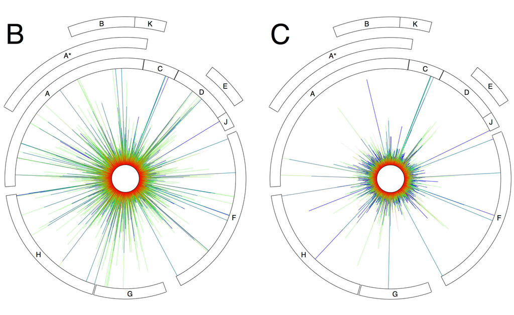

Two key findings of my work with the above workflows:

- evolutionary trajectories are reproducible only at low mutation rates
- fitness shows evidence of trade-offs upon host switching.

# Worked Example 2: Simulating Evolution

[Link to simulations](https://github.com/tethig/simulations/blob/master/DFEM_py_nb.ipynb)